# Testing Moderation Effects Using Simple Slopes Analysis

## Concept Section

Many students are introduced to the concept of interactions when they learn about ANOVAs. An interaction effect means that the effect of one independent variable on the dependent variable depends on the level of another independent variable.

We can examine the interaction effect of categorical variables on a dependent variable in simple 2x2 factorial design by first conducting an ANOVA, followed by post-hoc tests such as a Tukey HSD test to probe the interaction. These post-hoc tests compare the means of the two levels of one independent variable for one condition of the other independent variables. In an essence, these post-hoc tests are a series of t-tests that compare the 4 conditions in the 2x2 design. If any of the post-hoc tests are significant, the researcher can then refer to the means of the conditions to examine the nature of the interaction effect.

We can extend the concept of interactions to variables within a multiple linear regression model. For example, we may enter two predictor variables, as well as their interaction term, into a multiple linear regression model. An interaction effect within a regression model is usually referred to as a moderation effect. Conceptually, one of the independent variables is designated as a moderator of the relationship between the other independent variable and the dependent variable. Statistically, it does not make a difference which of the independent variables is designated as the moderator; this determination is typically made based on the theoretical background that is driving the hypothesis being tested.

In moderation analyses, it is common for the predictor variable and/or the moderator to be a continuous variable, rather than a categorical variable as is used in ANOVAs. Therefore, in moderation analyses, we may not have clearly defined groups that we are comparing, but rather we have variables that may be measured on a scale. For example, the construct of ‘stress’ can be defined as a categorical variable (high stress or low stress), or it can be a continuous variable, where you may have scores ranging from 1-10, with lower numbers indicating lower stress and higher numbers indicating higher stress. Therefore, in moderation analyses with continuous variables, we cannot use t-tests or similar post-hoc tests to probe a significant interaction effect, as we do not have discrete groups or conditions to compare.

Simple slopes is an analytic method that is commonly used to probe a significant moderation analysis within a multiple regression model. The simple slopes analysis examines whether there is a significant relationship between the predictor variable and dependent variable at a particular value of the moderator. It compares the effects of the moderator when it is low versus when it is high on the relationship between the predictor and the dependent variable. ‘Low’ is defined as the value of the moderator that is one standard deviation below the mean, while ‘high’ is defined as the value that is one standard deviation above the mean.

In this lab, we will use the PROCESS macro which was developed by Andrew F. Hayes, to test the moderation effect of one independent variable on the relationship between another independent variable and a dependent variable (Hayes, 2018). The PROCESS macro conducts a multiple regression analysis and can probe significant interaction effects using the simple slopes analysis. It also generates a data listing which can be used to plot the data.

In the practical section of the lab, we will use a dummy dataset to generate a simplified replication of real results (poster presenting the original findings can be viewed here: https://nepsych.org/wp-content/uploads/2020/10/Liat-Kofler-Kofler_Gao_EmpathyCUTraits.pdf).

In the example, we will examine the moderation effect of children’s respiratory sinus arrhythmia (RSA) on the relationship between parental empathy and children’s callous-unemotional traits (CU). CU traits include attributes such as uncaring behavior, shallow emotions, and attenuated guilt and empathy (Frick, Bodin & Barry, 2000). Parental traits and behaviors are known to affect children’s social and emotional development (Strayer & Roberts, 1989). The biological sensitivity to context theory indicates that some children may be more sensitive to, and consequently more strongly influenced by their environments, including social influences such as their parents (Boyce & Ellis, 2005). Specifically, the theory states that it is biological differences that make some children more susceptible than others to influences from their environments. RSA is a measure of parasympathetic nervous system activity, and may be an index of biological sensitivity. In the practical section, we will examine whether children’s RSA moderates the relationship between parental empathy and their children’s CU traits.

## Practical Section

First, we need to load the PROCESS macro. PROCESS is not available via a package. To use it, you need to go to the following link: https://www.processmacro.org/download.html

Download the zip file from this link. When you open the file, find the folder for the R code (as of May 2021, the folder is titled ‘PROCESS v3.5beta for R’). Within the folder, you will find an R file titled ‘PROCESS.R’. Open this R file, highlight the entire code, and run the code. It will take about 1-2 minutes for the code to run. Once you run it, you will then be able to use the PROCESS macro in R Studio. Note that you will need to do this every time you start a new session in R (if you want to use this function). *In order for this tutorial to output as an HTML file, the PROCESS source code (which is over 5000 lines long!) was embedded in the source code for this tutorial, however is hidden in the output HTML file.

Next, download the ‘EmpathyPsychopathyData’ data file from the following GitHub repository: https://github.com/liatkofler/StatsLabSpring21

Then, load the data in R (make sure to use the correct path):

```r
library(data.table)
Empathy_data_table <- fread("C:\\Users\\lkofl\\Documents\\School\\R Lab\\StatsLabSpring21\\EmpathyPsychopathyData.csv")
```

The data is now loaded in table form. The PROCESS function requires the data to be in a data frame. We will use the function setDF() to convert our data format from table to data frame:

```r
Empathy_data <- setDF(Empathy_data_table)
```

We will now run a moderation analysis using parental empathy as the predictor variable (i.e. the x or independent variable), child’s RSA as the moderator, and child’s CU traits as the outcome variable (the y or dependent variable).

First, the PROCESS function must be written in small letters. Within the function, we have to define the data we are using, as well as the y, x, and moderator variables. Note that the moderator is delineated as ‘w’.

We will also mean center continuous variables within the regression analysis. Mean centering is a process whereby the sample mean is subtracted from each data point of a variable. Mean centering is used to reduce multicollinearity when testing interactions between two variables where at least one variable is continuous, such as in our case. We thus set ‘center=2’ in our code.

Lastly, we set ‘moments=1’ in order to change the points at which we are probing the interaction to -1 and +1 standard deviations from the mean. If we do not define this, the output will provide the simple slope analysis at values that equal the 15th and 85th percentiles of the moderator.

```r
process(data=Empathy_data,y="CU",x="ParentEmpathy",w="RSA",model=1, center=2, moments=1)
```

```
##
## ***************** PROCESS for R Version 3.5.3 beta0.6 *****************
##
##            Written by Andrew F. Hayes, Ph.D.  www.afhayes.com
##    Documentation available in Hayes (2018). www.guilford.com/p/hayes3
##
##
## Model : 1
##     Y : CU
##     X : ParentEmpathy
##     W : RSA
##
## Sample size: 99
##
##
## Outcome Variable: CU
##
## Model Summary:
##           R      R-sq       MSE         F       df1       df2         p
##      0.3812    0.1453   56.7998    5.3854    3.0000   95.0000    0.0018
##
## Model:
##                   coeff        se         t         p      LLCI      ULCI
## constant        27.8143    0.7576   36.7123    0.0000   26.3102   29.3184
## ParentEmpathy   -0.4403    0.1951   -2.2569    0.0263   -0.8276   -0.0530
## RSA              0.0136    0.0124    1.0959    0.2759   -0.0110    0.0382
## Int_1           -0.0084    0.0030   -2.8569    0.0053   -0.0143   -0.0026
##
## Product terms key:
## Int_1  :  ParentEmpathy  x  RSA
##
## Test(s) of highest order unconditional interaction(s):
##       R2-chng         F       df1       df2         p
## X*W    0.0734    8.1616    1.0000   95.0000    0.0053
## ----------
## Focal predictor: ParentEmpathy (X)
##       Moderator: RSA (W)
##
## Conditional effects of the focal predictor at values of the moderator(s):
##         RSA    effect        se         t         p      LLCI      ULCI
##    -61.6692    0.0804    0.2785    0.2886    0.7735   -0.4725    0.6332
##     -0.0000   -0.4403    0.1951   -2.2569    0.0263   -0.8276   -0.0530
##     61.6692   -0.9610    0.2550   -3.7692    0.0003   -1.4672   -0.4548
##
## ******************** ANALYSIS NOTES AND ERRORS ************************
##
## Level of confidence for all confidence intervals in output: 95
##
## W values in conditional tables are the mean and +/- SD from the mean.
##
## NOTE: The following variables were mean centered prior to analysis:
##          RSA ParentEmpathy
```

First, we want to check whether our regression model is significant. To do so, we will first look at the model summary:

```r
#Model Summary:
#          R      R-sq       MSE         F       df1       df2         p
#     0.3812    0.1453   56.7998    5.3854    3.0000   95.0000    0.0018
```

Since p < .05, we conclude that the model is significant. Next, we can examine the main effects of parental empathy and child RSA on child CU traits, as well as the moderation effect on child CU traits by looking at the ‘model’ section of the output:

```r
#Model:
#                  coeff        se         t         p      LLCI      ULCI
#constant        27.8143    0.7576   36.7123    0.0000   26.3102   29.3184
#ParentEmpathy   -0.4403    0.1951   -2.2569    0.0263   -0.8276   -0.0530
#RSA              0.0136    0.0124    1.0959    0.2759   -0.0110    0.0382
#Int_1           -0.0084    0.0030   -2.8569    0.0053   -0.0143   -0.0026
```

The second row shows us the regression result for the main effect of parental empathy on child’s CU traits. Since the p-value is < .05, we conclude that there is a significant main effect of parental empathy. Looking at the regression coefficient, which is negative (coeff = -.4403), we conclude that as parental empathy increases, children’s CU traits decrease. The third row shows us that there is no significant main effect of child’s RSA on child’s CU traits, since p > .05. Lastly, we refer to the last row (‘Int_1’), which is the interaction effect. As p < .05, we can conclude that RSA moderates the relationship between parental empathy and child’s CU traits. To examine the nature of this moderation effect, we refer to the section of the output titled ‘conditional effects of the focal predictor at values of the moderator(s)’:

```r
#Conditional effects of the focal predictor at values of the moderator(s):
#        RSA    effect        se         t         p      LLCI      ULCI
#   -61.6692    0.0804    0.2785    0.2886    0.7735   -0.4725    0.6332
#    -0.0000   -0.4403    0.1951   -2.2569    0.0263   -0.8276   -0.0530
#    61.6692   -0.9610    0.2550   -3.7692    0.0003   -1.4672   -0.4548
```

The first column, titled ‘RSA’, shows us the effect of the moderator (child’s RSA) at three points: mean minus one standard deviation (RSA = -61.6692), at the mean (RSA = 0, because we mean centered this variable), and mean plus one standard deviation (RSA = 61.6692). This is the simple slopes analysis; we want to focus on the first and third row, which show as the effects of ‘low’ and ‘high’ RSA. Based on the p-values, we conclude that there is no significant moderation effect when RSA is low (p = .7735), but there is a significant moderation effect when RSA is high (p = .0003). Looking at the ‘effect’ coefficient, which is negative (effect = -.9610), we conclude that for children with higher RSA, higher parental empathy is associated with lower CU traits.

We can visualize this significant moderation effect by plotting the interaction. We can re-run the PROCESS function, and add ‘plot=1’ to the function. This will generate a dataset that can be used to plot the interaction:

```r
process(data=Empathy_data,y="CU",x="ParentEmpathy",w="RSA",model=1, center=2, moments=1, plot=1)
```

```
##
## ***************** PROCESS for R Version 3.5.3 beta0.6 *****************
##
##            Written by Andrew F. Hayes, Ph.D.  www.afhayes.com
##    Documentation available in Hayes (2018). www.guilford.com/p/hayes3
##
##
## Model : 1
##     Y : CU
##     X : ParentEmpathy
##     W : RSA
##
## Sample size: 99
##
##
## Outcome Variable: CU
##
## Model Summary:
##           R      R-sq       MSE         F       df1       df2         p
##      0.3812    0.1453   56.7998    5.3854    3.0000   95.0000    0.0018
##
## Model:
##                   coeff        se         t         p      LLCI      ULCI
## constant        27.8143    0.7576   36.7123    0.0000   26.3102   29.3184
## ParentEmpathy   -0.4403    0.1951   -2.2569    0.0263   -0.8276   -0.0530
## RSA              0.0136    0.0124    1.0959    0.2759   -0.0110    0.0382
## Int_1           -0.0084    0.0030   -2.8569    0.0053   -0.0143   -0.0026
##
## Product terms key:
## Int_1  :  ParentEmpathy  x  RSA
##
## Test(s) of highest order unconditional interaction(s):
##       R2-chng         F       df1       df2         p
## X*W    0.0734    8.1616    1.0000   95.0000    0.0053
## ----------
## Focal predictor: ParentEmpathy (X)
##       Moderator: RSA (W)
##
## Conditional effects of the focal predictor at values of the moderator(s):
##         RSA    effect        se         t         p      LLCI      ULCI
```

[output cut: 9 more lines]

```
##         -3.9185   -0.0000   29.5396
##         -0.0000   -0.0000   27.8143
##          3.9185   -0.0000   26.0889
##         -3.9185   61.6692   32.4174
##         -0.0000   61.6692   28.6518
##          3.9185   61.6692   24.8862
##
## ******************** ANALYSIS NOTES AND ERRORS ************************
##
## Level of confidence for all confidence intervals in output: 95
##
## W values in conditional tables are the mean and +/- SD from the mean.
##
## NOTE: The following variables were mean centered prior to analysis:
##          RSA ParentEmpathy
```

The dataset that can be used to plot the interaction is in the output section titled ‘Data for visualizing the conditional effect of the focal predictor’. We can copy and paste this dataset from the process function output, then use it to create a data frame using the tibble function. Begin by running the process function, and copying the data in the section titled “Data for visualizing the conditional effect of the focal predictor”. It should look as follows (without the # signs, which turn the data from lines of code to a comment):

```r
#  ParentEmpathy       RSA        CU
#        -3.9185  -61.6692   26.6618
#        -0.0000  -61.6692   26.9768
#         3.9185  -61.6692   27.2917
#        -3.9185   -0.0000   29.5396
#        -0.0000   -0.0000   27.8143
#         3.9185   -0.0000   26.0889
#        -3.9185   61.6692   32.4174
#        -0.0000   61.6692   28.6518
#         3.9185   61.6692   24.8862
```

As we are only interested in the points at the mean +/-1 SD, we can remove any data rows where parent empathy = 0 and/or where RSA = 0, as follows:

```r
#  ParentEmpathy       RSA        CU
#        -3.9185  -61.6692   26.6618
#         3.9185  -61.6692   27.2917
#        -3.9185   61.6692   32.4174
#         3.9185   61.6692   24.8862
```

We are now left with 4 data points that we want to plot. Note that for both the predictor and moderator variables (parent empathy and child RSA, respectively), the negative numbers represent the values at -1 SD, while the positive numbers represent the values at +1 SD. -1 SD represents lower values, while +1 represents higher values. We will enter this data into a tibble in order to create a data frame which we can later plot. When we enter the data into the tibble function, we will replace the negative values of the predictor and moderator variables with ‘low’ and the positive values with ‘high’. Note that we define the predictor and moderator as factors and set the order of the levels. This is done so that when we plot the data in the following step, the levels (‘low’ and ‘high’) are organized on the x-axis and within the legend in this order (low, then high); otherwise, ggplot (which is the function we will use to graph the plot) will organize the levels in alphabetical order (high, then low).

```r
library(tibble)

Plot_data<-tibble(
  ParentEmpathy=factor(c("Low","High","Low","High"),
       levels = c("Low","High")),
  RSA=factor(c("Low","Low","High","High"),
       levels = c("Low","High")),
  CU = c(26.6618,27.2917,32.4174,24.8862))
```

Now that we have our data frame, we can plot the data as we do with any interaction, using the ggplot function:

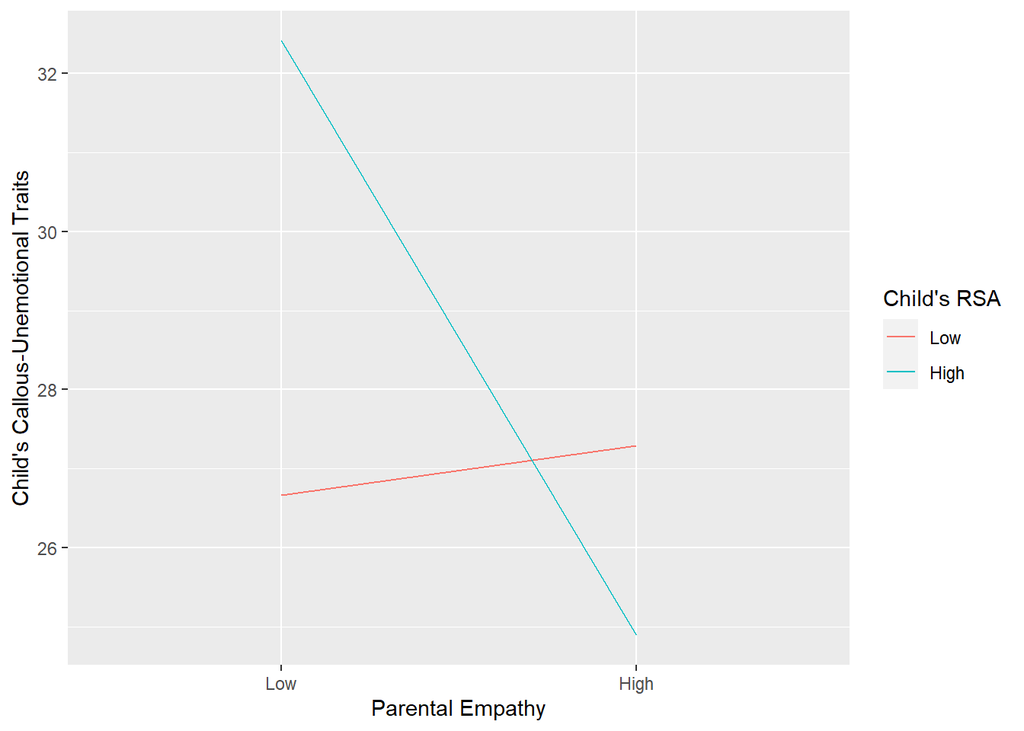

```r
library(ggplot2)

ggplot(Plot_data,aes(x=ParentEmpathy,y=CU,group=RSA,color=RSA))+
  geom_line()+xlab("Parental Empathy")+ylab("Child's Callous-Unemotional Traits")+labs(color="Child's RSA")
```

## Assignment Section

In the practical example we examined RSA, a measure of parasympathetic nervous system activity, as a moderator of the parental empathy and child CU traits association. For the generalization assignment, you will examine the role of skin conductance (SCL) as a moderator of the same relationship. SCL is a measure of sympathetic nervous system activity. We expect SCL to act in an inverse manner to RSA. While we found a negative association between parental empathy and child CU traits for children with high RSA, we expect the same negative association in children with low SCL. The assignment questions are as follows:

1. Create a graph of the expected results. Keeping the CU traits values the same as in the practical example, change the order of the ‘low’ and ‘high’ levels of the predictor and moderator variables to illustrate the expected outcome of the simple slopes analysis.
2. Conduct the regression and simple slopes analyses using the PROCESS function, examining the moderation effect of SCL on the relationship between parental empathy and child CU traits. Use the same datafile as in the practical example (“EmpathyPsychopathyData”). Is there a moderation effect of SCL on the relationship between parental empathy and child CU traits? If yes, describe the nature of the effect.
3. Plot the results of the simple slopes analysis from question 2. How does this graph compare to the graph you produced in question 1?

### Assignment answers

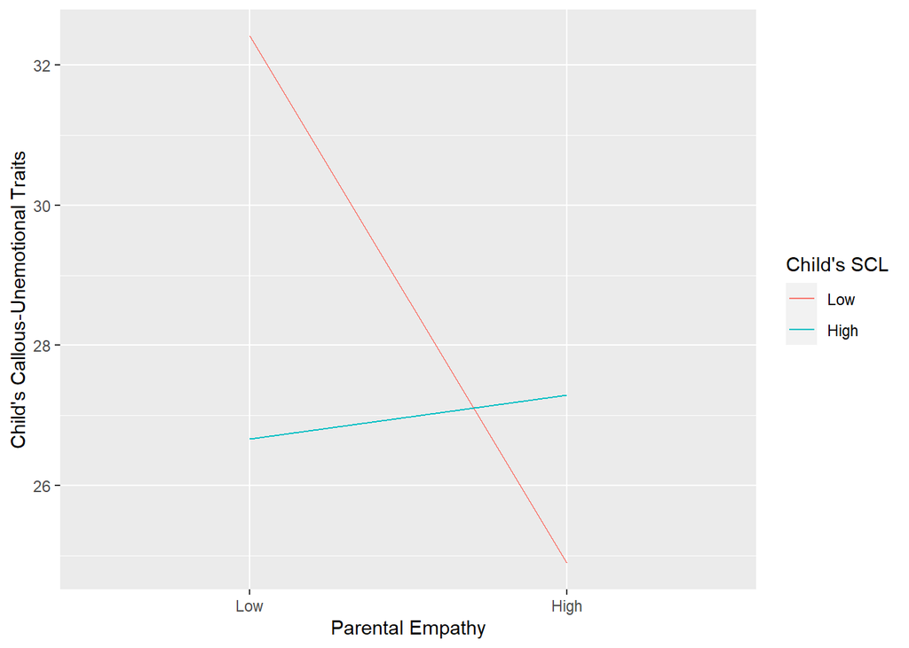

```r
Plot_data<-tibble(
  ParentEmpathy = factor(c("Low","High","Low","High"),
       levels = c("Low","High")),
  SCL = factor(c("High","High","Low","Low"),
       levels = c("Low","High")),
  CU = c(26.6618,27.2917,32.4174,24.8862))

ggplot(Plot_data,aes(x=ParentEmpathy,y=CU,group=SCL,color=SCL))+
  geom_line()+xlab("Parental Empathy")+ylab("Child's Callous-Unemotional Traits")+labs(color="Child's SCL")
```

```r
process(data=Empathy_data,y="CU",x="ParentEmpathy",w="SCL",model=1, center=2, moments=1)
```

```
##
## ***************** PROCESS for R Version 3.5.3 beta0.6 *****************
##
##            Written by Andrew F. Hayes, Ph.D.  www.afhayes.com
##    Documentation available in Hayes (2018). www.guilford.com/p/hayes3
##
##
## Model : 1
##     Y : CU
##     X : ParentEmpathy
##     W : SCL
##
## Sample size: 99
##
##
## Outcome Variable: CU
##
## Model Summary:
##           R      R-sq       MSE         F       df1       df2         p
##      0.3404    0.1159   58.7591    4.1500    3.0000   95.0000    0.0083
##
## Model:
##                   coeff        se         t         p      LLCI      ULCI
## constant        27.6081    0.7730   35.7140    0.0000   26.0734   29.1428
## ParentEmpathy   -0.5415    0.1996   -2.7135    0.0079   -0.9377   -0.1453
## SCL              0.0727    0.2157    0.3372    0.7367   -0.3554    0.5008
## Int_1            0.1152    0.0460    2.5066    0.0139    0.0240    0.2065
##
## Product terms key:
## Int_1  :  ParentEmpathy  x  SCL
##
## Test(s) of highest order unconditional interaction(s):
##       R2-chng         F       df1       df2         p
## X*W    0.0585    6.2829    1.0000   95.0000    0.0139
## ----------
## Focal predictor: ParentEmpathy (X)
##       Moderator: SCL (W)
##
## Conditional effects of the focal predictor at values of the moderator(s):
##         SCL    effect        se         t         p      LLCI      ULCI
##     -3.6105   -0.9575    0.2719   -3.5211    0.0007   -1.4974   -0.4177
##      0.0000   -0.5415    0.1996   -2.7135    0.0079   -0.9377   -0.1453
##      3.6105   -0.1256    0.2466   -0.5093    0.6117   -0.6150    0.3639
##
## ******************** ANALYSIS NOTES AND ERRORS ************************
##
## Level of confidence for all confidence intervals in output: 95
##
## W values in conditional tables are the mean and +/- SD from the mean.
##
## NOTE: The following variables were mean centered prior to analysis:
##          SCL ParentEmpathy
```

```r
#Run the process function, adding the plot code
process(data=Empathy_data,y="CU",x="ParentEmpathy",w="SCL",model=1, center=2, moments=1, plot = 1)
```

```
##
## ***************** PROCESS for R Version 3.5.3 beta0.6 *****************
##
##            Written by Andrew F. Hayes, Ph.D.  www.afhayes.com
##    Documentation available in Hayes (2018). www.guilford.com/p/hayes3
##
##
## Model : 1
##     Y : CU
##     X : ParentEmpathy
##     W : SCL
##
## Sample size: 99
##
##
## Outcome Variable: CU
##
## Model Summary:
##           R      R-sq       MSE         F       df1       df2         p
##      0.3404    0.1159   58.7591    4.1500    3.0000   95.0000    0.0083
##
## Model:
##                   coeff        se         t         p      LLCI      ULCI
## constant        27.6081    0.7730   35.7140    0.0000   26.0734   29.1428
## ParentEmpathy   -0.5415    0.1996   -2.7135    0.0079   -0.9377   -0.1453
## SCL              0.0727    0.2157    0.3372    0.7367   -0.3554    0.5008
## Int_1            0.1152    0.0460    2.5066    0.0139    0.0240    0.2065
##
## Product terms key:
## Int_1  :  ParentEmpathy  x  SCL
##
## Test(s) of highest order unconditional interaction(s):
##       R2-chng         F       df1       df2         p
## X*W    0.0585    6.2829    1.0000   95.0000    0.0139
## ----------
## Focal predictor: ParentEmpathy (X)
##       Moderator: SCL (W)
##
## Conditional effects of the focal predictor at values of the moderator(s):
##         SCL    effect        se         t         p      LLCI      ULCI
```

[output cut: 9 more lines]

```
##         -3.9185    0.0000   29.7301
##         -0.0000    0.0000   27.6081
##          3.9185    0.0000   25.4861
##         -3.9185    3.6105   28.3626
##         -0.0000    3.6105   27.8706
##          3.9185    3.6105   27.3786
##
## ******************** ANALYSIS NOTES AND ERRORS ************************
##
## Level of confidence for all confidence intervals in output: 95
##
## W values in conditional tables are the mean and +/- SD from the mean.
##
## NOTE: The following variables were mean centered prior to analysis:
##          SCL ParentEmpathy
```

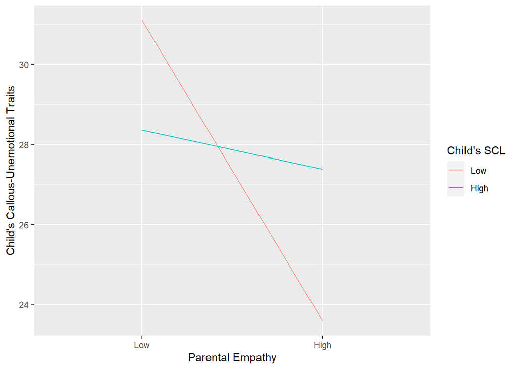

```r
#Generate a data frame and the associated plot using the plot data output from PROCESS

Plot_data<-tibble(
  ParentEmpathy = factor(c("Low","High","Low","High"),
         levels = c("Low","High")),
  SCL = factor(c("Low","Low","High","High"),
         levels = c("Low","High")),
  CU = c(31.0976,23.5935,28.3626,27.3786))

ggplot(Plot_data,aes(x=ParentEmpathy,y=CU,group=SCL,color=SCL))+
  geom_line()+xlab("Parental Empathy")+ylab("Child's Callous-Unemotional Traits")+labs(color="Child's SCL")
```

The graph is very similar to the graph we created in question 1 for the expected results.

```

## References

Boyce, W.T., & Ellis, B.J. (2005). Biological sensitivity to context: I. An evolutionary developmental theory of the origins and functions of stress reactivity. Development and Psychopathology, 17 (2), 271 301.

Frick, P. J., Bodin , S. D., & Barry, C. T. (2000). Psychopathic traits and conduct problems in community and clinic referred samples of children: further development of the psychopathy screening device. Psychological assessment 12 (4), 382 393.

Hayes, A.F. (2018). Introduction to mediation, moderation, and conditional process analysis: A regression-based approach. New York, NY: Guilford Press.

Strayer, J. & Roberts, W. (1989). Children’s empathy and role taking: Child and parental factors, and relations to prosocial behavior. Journal of Applied Developmental Psychology, 10 , 227 239.